# Biostat 203B Homework 4

Due Mar 19 @ 11:59PM

Dominic Shehtanian

Load database libraries and the tidyverse frontend:

```r
library(tidyverse)
library(lubridate)
library(miceRanger)
library(glmnet)
library(keras)
library(fastDummies)
```

**Note:** Knitting this the first time will take a long time due to the imputation. I saved the imputed data as a file as part of this code, but it is too large to host on GitHub.

## Q1. Missing data

Through the Shiny app developed in HW3, we observe abundant missing values in the MIMIC-IV ICU cohort we created. In this question, we use multiple imputation to obtain a data set without missing values.

0. Read following tutorials on the R package miceRanger for imputation: https://github.com/farrellday/miceRanger, https://cran.r-project.org/web/packages/miceRanger/vignettes/miceAlgorithm.html.

   A more thorough book treatment of the practical imputation strategies is the book [*Flexible Imputation of Missing Data*](https://stefvanbuuren.name/fimd/) by Stef van Buuren.
1. Explain the jargon MCAR, MAR, and MNAR.

**Solution:**

MCAR - Missing completely at random - The probability of being missing is unrelated to the value of the observations.

MAR - Missing at random - The probability of being missing depends only on observed values, not unobserved/missing values.

MNAR - Missing not at random - The probability of being missing depends on the value of the missing data.

2. Explain in a couple of sentences how the Multiple Imputation by Chained Equations (MICE) work.

**Solution**:

All missing values in the dataset are replaced by the mean for that variable, then one at a time, each variable with missing observations has those observations set back to missing (from their imputed values) and the observations are predicted using the other variables in the data set. This is repeated for until the data converges or a set number of cycles.

3. Perform a data quality check of the ICU stays data. Discard variables with substantial missingness, say >5000 `NA`s. Replace apparent data entry errors by `NA`s.

**Solution:**

I filtered extreme values based on observed ranges for these variables.

References: Based on [this article](https://pubmed.ncbi.nlm.nih.gov/7741618/#:~:text=The%20highest%20pressure%20recorded%20in,maximal%20lifting%20with%20slow%20exhalation.), it appears that the highest recorded blood pressure was 370.

Based on [this article](https://www.ncbi.nlm.nih.gov/pmc/articles/PMC3273956/#:~:text=The%20fastest%20human%20ventricular%20conduction%20rate%20reported%20to%20date%20is,of%20480%20beats%20per%20minute.), it appears the highest recorded heart rate was 480.

Based on [this article](http://www.atcs.jp/pdf/2008_14_3/138.pdf), I chose 60 degrees Fahrenheit as the lowest reasonable temperature reading for a living patient.

```r
#Reading in the ICU Cohort Data
icudata <- readRDS("./icu_cohort.rds")
summary(icudata)
```

```
##    subject_id          hadm_id            stay_id         first_careunit
##  Min.   :10000032   Min.   :20000094   Min.   :30000010   Length:49971
##  1st Qu.:12487232   1st Qu.:22464829   1st Qu.:32517740   Class :character
##  Median :14996888   Median :24936603   Median :34993438   Mode  :character
##  Mean   :14992943   Mean   :24966774   Mean   :34999702
##  3rd Qu.:17500650   3rd Qu.:27472734   3rd Qu.:37491891
##  Max.   :19999987   Max.   :29999828   Max.   :39999149
##
##  last_careunit          intime                       outtime
##  Length:49971       Min.   :2110-01-11 02:16:06   Min.   :2110-01-12 09:17:47
##  Class :character   1st Qu.:2132-11-28 14:54:00   1st Qu.:2132-12-01 23:17:11
##  Mode  :character   Median :2152-11-02 09:41:42   Median :2152-11-05 10:35:54
##                     Mean   :2152-11-22 01:03:01   Mean   :2152-11-25 19:52:35
##                     3rd Qu.:2172-11-26 07:48:30   3rd Qu.:2172-11-29 23:46:34
##                     Max.   :2210-06-27 07:39:30   Max.   :2210-06-29 15:23:43
##
##       los              admittime
##  Min.   :  0.03469   Min.   :2110-01-11 02:14:00
##  1st Qu.:  1.11811   1st Qu.:2132-11-27 13:08:00
##  Median :  1.99216   Median :2152-10-31 13:11:00
##  Mean   :  3.78443   Mean   :2152-11-21 00:15:59
##  3rd Qu.:  4.01308   3rd Qu.:2172-11-26 06:22:00
##  Max.   :222.88872   Max.   :2210-06-26 09:00:00
##
##    dischtime                     deathtime                   admission_type
##  Min.   :2110-01-15 09:31:00   Min.   :2110-01-25 01:40:00   Length:49971
##  1st Qu.:2132-12-09 07:26:30   1st Qu.:2132-06-03 10:33:00   Class :character
##  Median :2152-11-08 08:51:00   Median :2152-02-26 16:01:00   Mode  :character
##  Mean   :2152-11-30 09:21:43   Mean   :2152-05-16 17:24:15
##  3rd Qu.:2172-12-04 08:49:00   3rd Qu.:2172-05-29 01:36:00
##  Max.   :2210-06-30 10:30:00   Max.   :2209-07-31 09:10:00
##                                NA's   :44796
##  admission_location discharge_location  insurance           language
##  Length:49971       Length:49971       Length:49971       Length:49971
##  Class :character   Class :character   Class :character   Class :character
##  Mode  :character   Mode  :character   Mode  :character   Mode  :character
##
##
##
##
```

[output cut: 57 more lines]

```
##  Min.   : 0.000   Min.   : 0.800   Min.   : 92.0   Min.   : 4.30
##  1st Qu.: 1.700   1st Qu.: 3.700   1st Qu.:136.0   1st Qu.:28.10
##  Median : 2.000   Median : 4.100   Median :139.0   Median :32.60
##  Mean   : 1.999   Mean   : 4.165   Mean   :138.5   Mean   :32.74
##  3rd Qu.: 2.200   3rd Qu.: 4.500   3rd Qu.:141.0   3rd Qu.:37.20
##  Max.   :47.000   Max.   :13.000   Max.   :180.0   Max.   :68.60
##  NA's   :1009     NA's   :848      NA's   :822     NA's   :1009
##       wbc           lactate       days_to_death     died_within_30d
##  Min.   :  0.0   Min.   : 0.200   Length:49971      Mode :logical
##  1st Qu.:  7.6   1st Qu.: 1.200   Class :difftime   FALSE:44997
##  Median : 10.5   Median : 1.800   Mode  :numeric    TRUE :4974
##  Mean   : 12.0   Mean   : 2.286
##  3rd Qu.: 14.4   3rd Qu.: 2.700
##  Max.   :572.5   Max.   :37.000
##  NA's   :1026    NA's   :19798
```

```r
#Dropping variables with >5000 NAs and variables that won't be used for analysis
icudata_filtered <- select(icudata, -deathtime, -edregtime, -edouttime, -dod,
                           -arterial_blood_pressure_systolic,
                           -arterial_blood_pressure_mean, -lactate,
                           -days_to_death, -subject_id, -hadm_id, -stay_id,
                           -intime, -outtime, -los, -admittime, -dischtime,
                           -deathtime, -anchor_age, -anchor_year,
                           -anchor_year_group, -first_careunit, -last_careunit,
                           -admission_type, -admission_location,
                           -discharge_location, -hospital_expire_flag)

#Replacing probable data entry errors with NA
icudata_filtered$non_invasive_blood_pressure_systolic[
  icudata_filtered$non_invasive_blood_pressure_systolic > 370] <- NA

icudata_filtered$non_invasive_blood_pressure_mean[
  icudata_filtered$non_invasive_blood_pressure_mean > 370] <- NA

icudata_filtered$heart_rate[icudata_filtered$heart_rate > 480] <- NA

icudata_filtered$temperature_fahrenheit[
  icudata_filtered$temperature_fahrenheit < 60] <- NA

summary(icudata_filtered)
```

```
##   insurance           language         marital_status      ethnicity
##  Length:49971       Length:49971       Length:49971       Length:49971
##  Class :character   Class :character   Class :character   Class :character
##  Mode  :character   Mode  :character   Mode  :character   Mode  :character
##
##
##
##
##     gender            age_at_adm       heart_rate
##  Length:49971       Min.   : 19.00   Min.   :  0.0
##  Class :character   1st Qu.: 54.00   1st Qu.: 74.0
##  Mode  :character   Median : 66.00   Median : 85.0
##                     Mean   : 64.52   Mean   : 87.5
##                     3rd Qu.: 78.00   3rd Qu.: 99.0
##                     Max.   :102.00   Max.   :247.0
##                                      NA's   :9
##  non_invasive_blood_pressure_systolic non_invasive_blood_pressure_mean
##  Min.   :  0.0                        Min.   :  0.00
##  1st Qu.:106.0                        1st Qu.: 69.00
##  Median :122.0                        Median : 80.00
##  Mean   :123.5                        Mean   : 81.99
##  3rd Qu.:139.0                        3rd Qu.: 93.00
##  Max.   :259.0                        Max.   :220.00
##  NA's   :573                          NA's   :597
##  respiratory_rate temperature_fahrenheit  bicarbonate       calcium
##  Min.   :  0.00   Min.   : 80.00         Min.   : 2.00   Min.   : 0.000
##  1st Qu.: 15.00   1st Qu.: 97.60         1st Qu.:21.00   1st Qu.: 7.900
##  Median : 18.00   Median : 98.10         Median :23.00   Median : 8.400
##  Mean   : 18.67   Mean   : 98.16         Mean   :23.07   Mean   : 8.349
##  3rd Qu.: 22.00   3rd Qu.: 98.70         3rd Qu.:26.00   3rd Qu.: 8.800
##  Max.   :180.00   Max.   :106.00         Max.   :49.00   Max.   :43.000
##  NA's   :34       NA's   :923            NA's   :857     NA's   :2366
##     chloride       creatinine        glucose       magnesium
##  Min.   : 58.0   Min.   : 0.000   Min.   :   7   Min.   : 0.000
##  1st Qu.:101.0   1st Qu.: 0.700   1st Qu.: 103   1st Qu.: 1.700
##  Median :105.0   Median : 0.900   Median : 124   Median : 2.000
##  Mean   :104.6   Mean   : 1.305   Mean   : 141   Mean   : 1.999
##  3rd Qu.:108.0   3rd Qu.: 1.300   3rd Qu.: 156   3rd Qu.: 2.200
##  Max.   :153.0   Max.   :36.900   Max.   :2440   Max.   :47.000
##  NA's   :831     NA's   :835      NA's   :846    NA's   :1009
##    potassium          sodium        hematocrit         wbc
##  Min.   : 0.800   Min.   : 92.0   Min.   : 4.30   Min.   :  0.0
##  1st Qu.: 3.700   1st Qu.:136.0   1st Qu.:28.10   1st Qu.:  7.6
##  Median : 4.100   Median :139.0   Median :32.60   Median : 10.5
##  Mean   : 4.165   Mean   :138.5   Mean   :32.74   Mean   : 12.0
##  3rd Qu.: 4.500   3rd Qu.:141.0   3rd Qu.:37.20   3rd Qu.: 14.4
##  Max.   :13.000   Max.   :180.0   Max.   :68.60   Max.   :572.5
##  NA's   :848      NA's   :822     NA's   :1009    NA's   :1026
##  died_within_30d
##  Mode :logical
##  FALSE:44997
##  TRUE :4974
##
##
##
##
```

Based on the summary of icudata, I removed deathtime, edregtime, edouttime, dod, arterial blood pressure - systolic, arterial blood pressure - mean, lactate, and days to death for large amounts of missing data. I replaced apparent data entry errors in heart rate, non-invasive blood pressure - systolic, non-invasive blood pressure - mean, and temperature (Farenheit) with `NA`.

4. Impute missing values by `miceRanger` (request $m=3$ datasets). This step is very computational intensive. Make sure to save the imputation results as a file.

```r
#max depth needed to be set otherwise my R instance would crash on the
#teaching server
seqTime <- system.time(
  miceObj <- miceRanger(
    icudata_filtered, m = 3,
    max.depth = 10,
    returnModels = TRUE, verbose = TRUE))
```

```
## One or more of the specified variables to impute contains no missing values. These will remain as a predictor, however they will not be imputed.
```

```
## Converting characters to factors.
```

```
##
## Process started at 2021-03-18 11:34:41
```

[output not shown]

```r
miceObj %>% saveRDS('./imputation_data')
```

```r
impute_data <- readRDS('./imputation_data')
```

5. Make imputation diagnostic plots and explain what they mean.

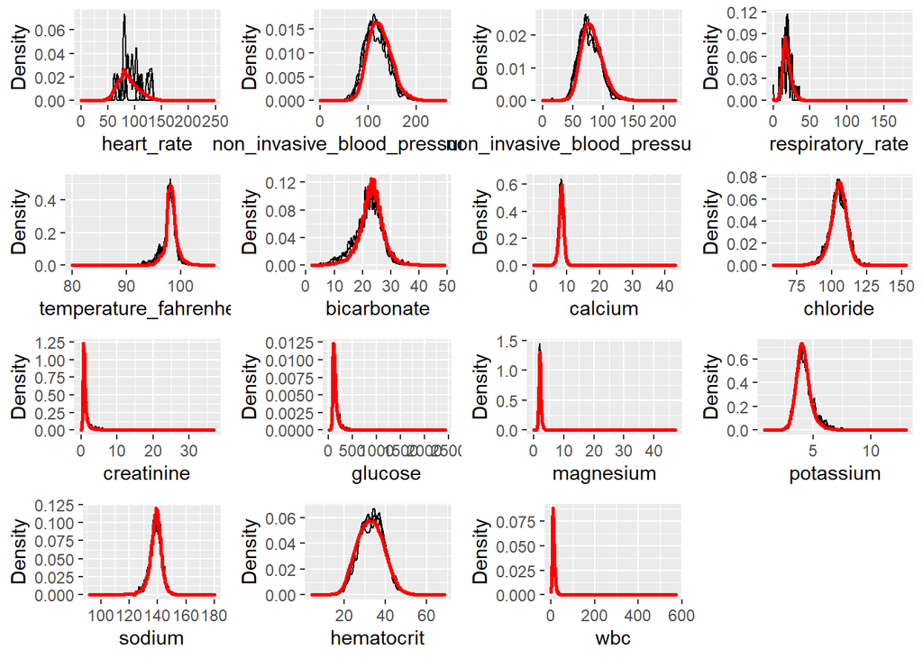

```r
plotDistributions(impute_data, vars = 'allNumeric')
```

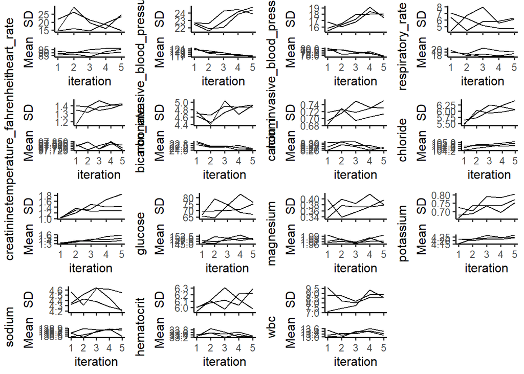

```r
plotVarConvergence(impute_data, vars = 'allNumeric')
```

**Solution:** The first set of plots shows the distribution of the original data (in red) and the imputed data (in black). For most of the variable these match fairly closely. However, for heart rate appears to have very large deviations and respiratory rate and hematocrit have noticeable deviations. This implies that data is not missing completely at random.

I ran the imputation with a max depth of 20 on my personal computer and many variables still had issues with convergence. I limited the max depth to ten, due to performance issues on the teaching server.

6. Obtain a complete data set by averaging the 3 imputed data sets.

```r
icu_imputed <- completeData(impute_data)
#Need to convert to matrix to average
#Reconverted to data frame to use column names in part 2
#dummy_cols transforms character variables in multiple variables
#(i.e gender become gender_M and gender_F, where gender_F = 1 when gender = F)
icu_imputed$Dataset_1 <- dummy_cols(icu_imputed$Dataset_1) %>%
  select(-insurance, -language, -marital_status, -ethnicity, -gender)
icu_imputed$Dataset_2 <- dummy_cols(icu_imputed$Dataset_2) %>%
  select(-insurance, -language, -marital_status, -ethnicity, -gender)
icu_imputed$Dataset_3 <- dummy_cols(icu_imputed$Dataset_3) %>%
  select(-insurance, -language, -marital_status, -ethnicity, -gender)
icu_analysis <- data.frame((data.matrix(icu_imputed$Dataset_1) +
                              data.matrix(icu_imputed$Dataset_2) +
                              data.matrix(icu_imputed$Dataset_3)) / 3)
head(icu_analysis)
```

```
##   age_at_adm heart_rate non_invasive_blood_pressure_systolic
## 1         76         77                                  150
## 2         51         87                                  167
## 3         61        114                                  109
## 4         58         79                                   85
## 5         70         69                                  125
## 6         78         70                                   93
##   non_invasive_blood_pressure_mean respiratory_rate temperature_fahrenheit
## 1                               92               23                   98.0
## 2                              117               22                   99.4
## 3                               70               20                   98.8
## 4                               60               16                   98.6
## 5                               83               15                   96.9
## 6                               62               18                   98.5
##   bicarbonate calcium chloride creatinine glucose magnesium potassium sodium
```

[output cut: 55 more lines]

## Q2. Predicting 30-day mortality

Develop at least two analytic approaches for predicting the 30-day mortality of patients admitted to ICU using demographic information (gender, age, marital status, ethnicity), first lab measurements during ICU stay, and first vital measurements during ICU stay. For example, you can use (1) logistic regression (`glm()` function), (2) logistic regression with lasso penalty (glmnet package), (3) random forest (randomForest package), or (4) neural network.

1. Partition data into 80% training set and 20% test set. Stratify partitioning according the 30-day mortality status.

```r
#Stratifying by 30-day mortality status
d30_true <- icu_analysis[
  icu_analysis$died_within_30d == 1, 1:ncol(icu_analysis)]
d30_false <- icu_analysis[
  icu_analysis$died_within_30d == 0, 1:ncol(icu_analysis)]
#Sampling from to build our training and test sets
train_size30T <- round(nrow(d30_true) * .8)
train_size30F <- round(nrow(d30_false) * .8)
smpl_true <- sample(1:nrow(d30_true), train_size30T)
smpl_false <- sample(1:nrow(d30_false), train_size30F)

#Recombines training data of 30-day mortality TRUE and FALSE
icu_train <- rbind(d30_true[smpl_true,1:ncol(icu_analysis)],
                   d30_false[smpl_false,1:ncol(icu_analysis)])
#Randomizes the rows, without doing this I got weird validation accuracy
#Without doing this all 30-day mortality TRUE come before FALSE
rows <- sample(nrow(icu_train))
icu_train <- icu_train[rows, ]
#creating x_train and y_train for Neural Network/Logistic Regression
x_train <- model.matrix(died_within_30d ~ -1 + gender_F + gender_M +
                          age_at_adm + marital_status_DIVORCED +
                          marital_status_MARRIED + marital_status_SINGLE +
                          marital_status_WIDOWED +
                          ethnicity_AMERICAN.INDIAN.ALASKA.NATIVE +
                          ethnicity_ASIAN + ethnicity_BLACK.AFRICAN.AMERICAN +
                          ethnicity_HISPANIC.LATINO + ethnicity_OTHER +
                          ethnicity_WHITE + ethnicity_UNABLE.TO.OBTAIN +
                          ethnicity_UNKNOWN + heart_rate +
                          non_invasive_blood_pressure_systolic +
                          non_invasive_blood_pressure_mean +
                          respiratory_rate + temperature_fahrenheit +
                          bicarbonate + calcium + chloride + creatinine +
                          glucose + magnesium + potassium + sodium +
                          hematocrit + wbc, data = icu_train)
y_train <- to_categorical(data.matrix(icu_train$died_within_30d), 2)

#Recombines test data of 30-day mortality TRUE and FALSE
icu_test <- rbind(d30_true[-smpl_true, 1:ncol(icu_analysis)],
                  d30_false[-smpl_false, 1:ncol(icu_analysis)])
#Randomizes the rows
rows <- sample(nrow(icu_test))
icu_test <- icu_test[rows, ]
#creating x_train and y_train for Neural Network/Logistic Regression
x_test <- model.matrix(died_within_30d ~ -1 + gender_F + gender_M +
                          age_at_adm + marital_status_DIVORCED +
                          marital_status_MARRIED + marital_status_SINGLE +
                          marital_status_WIDOWED +
                          ethnicity_AMERICAN.INDIAN.ALASKA.NATIVE +
                          ethnicity_ASIAN + ethnicity_BLACK.AFRICAN.AMERICAN +
                          ethnicity_HISPANIC.LATINO + ethnicity_OTHER +
                          ethnicity_WHITE + ethnicity_UNABLE.TO.OBTAIN +
                          ethnicity_UNKNOWN + heart_rate +
                          non_invasive_blood_pressure_systolic +
                          non_invasive_blood_pressure_mean +
                          respiratory_rate + temperature_fahrenheit +
                          bicarbonate + calcium + chloride + creatinine +
                          glucose + magnesium + potassium + sodium +
                          hematocrit + wbc, data = icu_test)
y_test <- to_categorical(data.matrix(icu_test$died_within_30d), 2)
```

2. Train the models using the training set.

```r
#Neural Network

model <- keras_model_sequential()
model %>%
  layer_dense(units = 8, activation = 'relu', input_shape = c(30)) %>%
  layer_dropout(rate = 0.4) %>%
  layer_dense(units = 4, activation = 'relu') %>%
  layer_dropout(rate = 0.3) %>%
  layer_dense(units = 2, activation = 'softmax')
summary(model)
```

```
## Model: "sequential"
## ________________________________________________________________________________
## Layer (type)                        Output Shape                    Param #
## ================================================================================
## dense_2 (Dense)                     (None, 8)                       248
## ________________________________________________________________________________
## dropout_1 (Dropout)                 (None, 8)                       0
## ________________________________________________________________________________
## dense_1 (Dense)                     (None, 4)                       36
## ________________________________________________________________________________
## dropout (Dropout)                   (None, 4)                       0
## ________________________________________________________________________________
## dense (Dense)                       (None, 2)                       10
## ================================================================================
## Total params: 294
## Trainable params: 294
## Non-trainable params: 0
## ________________________________________________________________________________
```

```r
model %>% compile(
  loss = 'categorical_crossentropy',
  optimizer = optimizer_rmsprop(),
  metrics = c('accuracy')
)
model
```

```
## Model
## Model: "sequential"
## ________________________________________________________________________________
## Layer (type)                        Output Shape                    Param #
## ================================================================================
## dense_2 (Dense)                     (None, 8)                       248
## ________________________________________________________________________________
## dropout_1 (Dropout)                 (None, 8)                       0
## ________________________________________________________________________________
## dense_1 (Dense)                     (None, 4)                       36
## ________________________________________________________________________________
## dropout (Dropout)                   (None, 4)                       0
## ________________________________________________________________________________
## dense (Dense)                       (None, 2)                       10
## ================================================================================
## Total params: 294
## Trainable params: 294
## Non-trainable params: 0
## ________________________________________________________________________________
```

```r
system.time({
history <- model %>% fit(
  x_train, y_train,
  epochs = 30, batch_size = 128,
  validation_split = 0.2
)
})
```

```
##    user  system elapsed
##   20.38    0.94   14.92
```

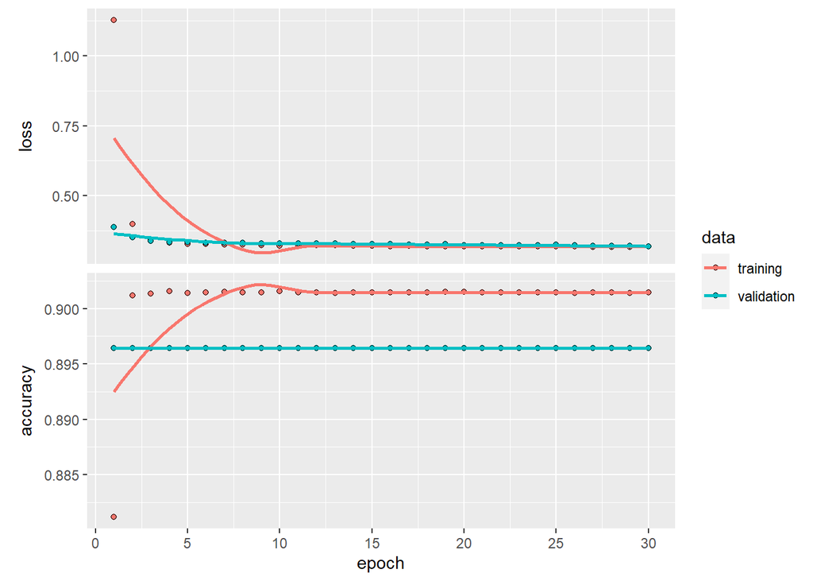

```r
plot(history)
```

```r
# Logistic Regression
mlogit <- keras_model_sequential()
mlogit %>% layer_dense(units = 2, activation = 'softmax', input_shape = c(30))
summary(mlogit)
```

```
## Model: "sequential_1"
## ________________________________________________________________________________
## Layer (type)                        Output Shape                    Param #
## ================================================================================
## dense_3 (Dense)                     (None, 2)                       62
## ================================================================================
## Total params: 62
## Trainable params: 62
## Non-trainable params: 0
## ________________________________________________________________________________
```

```r
mlogit %>% compile(
  loss = 'categorical_crossentropy',
  optimizer = optimizer_rmsprop(),
  metrics = c('accuracy')
)
mlogit
```

```
## Model
## Model: "sequential_1"
## ________________________________________________________________________________
## Layer (type)                        Output Shape                    Param #
## ================================================================================
## dense_3 (Dense)                     (None, 2)                       62
## ================================================================================
## Total params: 62
## Trainable params: 62
## Non-trainable params: 0
## ________________________________________________________________________________
```

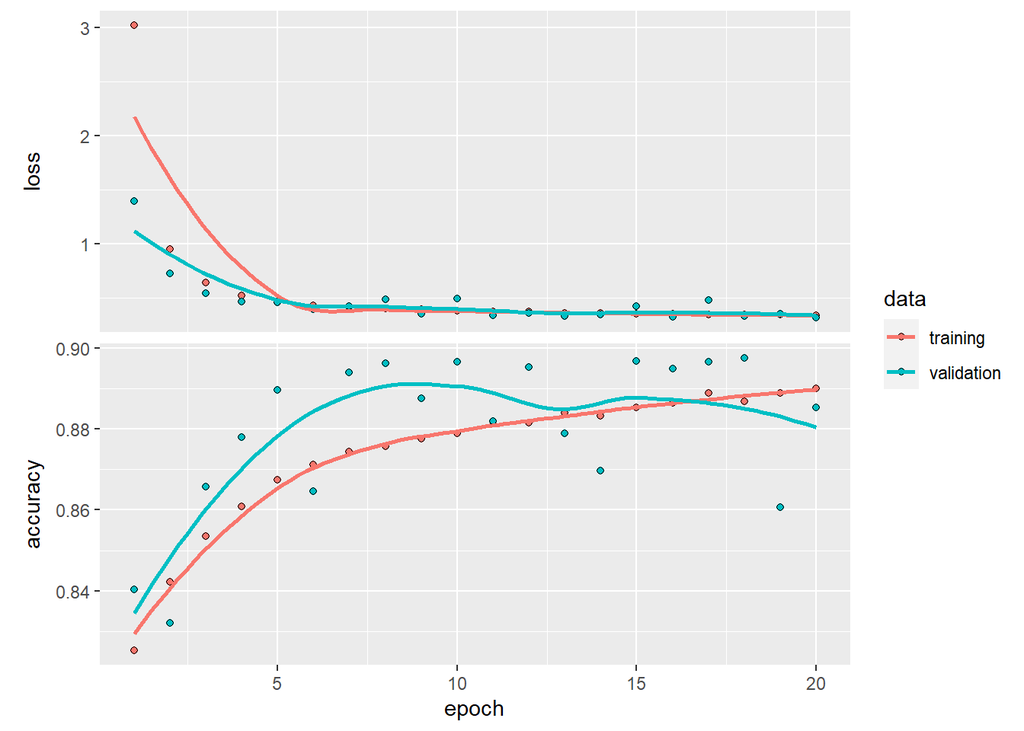

```r
mlogit_history <- mlogit %>% fit(
  x_train, y_train,
  epochs = 20, batch_size = 128,
  validation_split = 0.2
)

plot(mlogit_history)
```

3. Compare model prediction performance on the test set.

```r
#Neural Network
model %>% evaluate(x_test, y_test)
```

```
##      loss  accuracy
## 0.3108835 0.9004403
```

```r
#Logistic Regression
mlogit %>% evaluate(x_test, y_test)
```

```
##      loss  accuracy
## 0.3190395 0.8854312
```

**Solution:** The neural network appears to have a slightly smaller loss and slightly greater accuracy than the logistic regression. I would consider the neural network to have better performance in this case.